# Practical Machine Learning Prediction Assignment Writeup

Brian Lewis

Thursday, July 23, 2015

## *SUMMARY*

The goal of this project is to predict the manner in which a group of fitness enthusiasts performed exercises, based on devices such as Jawbone Up, Nike FuelBand, and Fitbit which make it possible to collect a large amount of data about personal activity relatively inexpensively.

Using data from accelerometers on the belt, forearm, arm, and dumbell of 6 participants who were asked to perform barbell lifts correctly and incorrectly in 5 different ways. This is the “classe” variable in the training set.

You may use any of the other variables to predict with. You should create a report describing how you built your model, how you used cross validation, what you think the expected out of sample error is, and why you made the choices you did. You will also use your prediction model to predict 20 different test cases.

## *LOAD DATA*

Load the training data (19,622 records and 160 variables).

```r
training <- read.csv("pml-training.csv", header=T, sep=",", na.strings=c("NA",""))
testing <- read.csv("pml-testing.csv", header=T,sep=",", na.strings=c("NA",""))
dim(training)
```

```
## [1] 19622   160
```

## *CLEAN DATA*

```r
validCol <- colSums(!is.na(training[,-ncol(training)]))>=0.7*nrow(training)
training <- training[,validCol]
testing <- testing[,validCol]
dim(training)
```

```
## [1] 19622    60
```

Remove unnecessary columns (7 variables, leaving 53 variables, 52 predictors and 1 response).

```r
colRm_train <- c("X","user_name","raw_timestamp_part_1","raw_timestamp_part_2","cvtd_timestamp","num_window", "new_window")
training <- training[,!(names(training) %in% colRm_train)]
testing <- testing[,!(names(training) %in% colRm_train)]
dim(training)
```

```
## [1] 19622    53
```

## *CREATE VALIDATION DATA SET*

Split the cleaned training data into a training set and a validation set.

```r
library(caret)
set.seed(53)
InTrain <- createDataPartition(y=training$classe, p=0.7, list=FALSE)
training <- training[InTrain,]
validation <- training[-InTrain,]
```

## *CHOOSE MODEL*

Check the correlations between the 52 predictors and the outcome variable, ‘classe’, in the training set.

```r
corr <- abs(sapply(colnames(training[, -ncol(training)]), function(x) cor(as.numeric(training[, x]), as.numeric(training$classe), method = "spearman")))
print(corr)
```

```
##            roll_belt           pitch_belt             yaw_belt
##         1.286156e-01         4.553346e-02         7.442948e-02
##     total_accel_belt         gyros_belt_x         gyros_belt_y
##         9.198640e-02         1.431413e-02         2.208284e-03
##         gyros_belt_z         accel_belt_x         accel_belt_y
##         2.688384e-05         4.273881e-02         1.597856e-02
##         accel_belt_z        magnet_belt_x        magnet_belt_y
##         1.360349e-01         1.358028e-03         1.963680e-01
##        magnet_belt_z             roll_arm            pitch_arm
##         1.398660e-01         4.696098e-02         1.860486e-01
##              yaw_arm      total_accel_arm          gyros_arm_x
##         2.931629e-02         1.532732e-01         2.002194e-02
##          gyros_arm_y          gyros_arm_z          accel_arm_x
##         3.052474e-02         1.457336e-02         2.603320e-01
##          accel_arm_y          accel_arm_z         magnet_arm_x
##         8.087833e-02         1.050028e-01         2.861873e-01
##         magnet_arm_y         magnet_arm_z        roll_dumbbell
##         2.662319e-01         1.568133e-01         9.114408e-02
##       pitch_dumbbell         yaw_dumbbell total_accel_dumbbell
##         9.521594e-02         3.707886e-03         7.703103e-03
##     gyros_dumbbell_x     gyros_dumbbell_y     gyros_dumbbell_z
##         1.005230e-02         2.204563e-02         1.322029e-02
##     accel_dumbbell_x     accel_dumbbell_y     accel_dumbbell_z
##         1.226561e-01         9.907574e-03         7.375059e-02
##    magnet_dumbbell_x    magnet_dumbbell_y    magnet_dumbbell_z
##         1.501610e-01         4.662570e-02         2.011967e-01
##         roll_forearm        pitch_forearm          yaw_forearm
##         5.569442e-02         3.235095e-01         4.818550e-02
##  total_accel_forearm      gyros_forearm_x      gyros_forearm_y
##         1.245422e-01         9.994783e-03         3.223785e-03
##      gyros_forearm_z      accel_forearm_x      accel_forearm_y
##         5.720708e-03         2.084766e-01         1.503507e-02
##      accel_forearm_z     magnet_forearm_x     magnet_forearm_y
##         6.595904e-03         1.987251e-01         1.182712e-01
##     magnet_forearm_z
##         4.867300e-02
```

Since none of the predictors show strong correlated with the outcome variable (the highest being r = 0.324 for ‘pitch_forearm’), random forest modelling may be a better choice than linear regression modelling this data.

## *MODEL USING RANDOM FOREST*

Fit a model using the Random Forest Method.

```r
library(randomForest)
set.seed(53)
modelFit<-randomForest(classe~.,data=training,importance=TRUE)
modelFit
```

```
##
## Call:
##  randomForest(formula = classe ~ ., data = training, importance = TRUE)
##                Type of random forest: classification
##                      Number of trees: 500
## No. of variables tried at each split: 7
##
##         OOB estimate of  error rate: 0.49%
## Confusion matrix:
##      A    B    C    D    E class.error
## A 3901    4    0    0    1 0.001280082
## B   13 2637    8    0    0 0.007900677
## C    0   12 2382    2    0 0.005843072
## D    0    0   20 2230    2 0.009769094
## E    0    0    1    4 2520 0.001980198
```

## *EVALUATE MODEL FIT*

Verify variable importance measures

```r
importance(modelFit)
```

```
##                             A        B        C        D        E
## roll_belt            35.76415 46.13748 43.33680 42.43706 42.33058
## pitch_belt           30.78873 49.57982 39.71049 33.45353 32.32286
## yaw_belt             46.83638 41.72973 41.29238 43.62665 33.66083
## total_accel_belt     14.75732 17.32944 14.54390 15.17639 16.35918
## gyros_belt_x         18.23365 17.40994 19.24951 14.28114 17.01082
## gyros_belt_y         12.80025 15.82707 17.63076 14.79675 18.15425
## gyros_belt_z         20.85120 28.05281 26.05637 21.54757 27.28775
## accel_belt_x         14.69952 17.82504 17.15171 13.84973 15.67717
## accel_belt_y         12.75075 16.26580 14.30989 16.00692 14.04725
## accel_belt_z         20.15587 25.13223 23.33703 20.11454 18.84007
## magnet_belt_x        18.34487 28.20966 26.40683 21.23256 24.36013
## magnet_belt_y        22.51598 26.85075 27.03843 26.07655 23.22467
## magnet_belt_z        22.76248 26.92229 23.42724 27.51771 24.89356
## roll_arm             20.91458 29.47358 28.71972 28.53885 21.93608
## pitch_arm            16.57830 21.86607 21.61451 17.60974 16.37766
## yaw_arm              24.47308 24.90759 25.18681 24.83262 20.23057
## total_accel_arm      10.54348 24.60153 21.31595 19.20126 18.84534
## gyros_arm_x          16.10439 25.22283 21.46327 22.29751 21.49588
## gyros_arm_y          18.90863 31.17140 23.08677 26.40053 22.91228
## gyros_arm_z          12.84871 17.84110 15.73308 15.21095 14.25925
## accel_arm_x          17.71501 19.76162 20.87947 22.22474 16.38314
## accel_arm_y          17.07703 23.20012 18.68827 18.80416 17.39596
## accel_arm_z          13.11868 18.77123 21.72018 20.64177 18.04325
## magnet_arm_x         18.20212 18.33158 21.64002 19.93629 17.15851
## magnet_arm_y         13.35683 17.81268 19.28156 21.98577 15.31933
## magnet_arm_z         22.00299 23.82862 22.12902 20.59601 17.93129
## roll_dumbbell        22.19435 26.76955 27.93656 27.32578 25.19170
## pitch_dumbbell       12.06144 19.13885 17.33509 13.12344 14.58175
## yaw_dumbbell         17.48682 25.61141 25.60947 22.69108 23.81046
## total_accel_dumbbell 19.71406 22.84768 19.98464 22.54727 24.17609
## gyros_dumbbell_x     17.99817 24.89378 22.64111 18.06878 20.37378
## gyros_dumbbell_y     20.87849 21.82637 27.31312 21.87729 18.77035
## gyros_dumbbell_z     17.62491 23.93479 18.56333 17.45125 16.56099
## accel_dumbbell_x     18.17449 23.45260 21.50898 19.16249 19.54483
## accel_dumbbell_y     28.76927 30.78347 31.64448 28.36461 28.44249
## accel_dumbbell_z     23.12243 30.01622 27.36625 27.21208 29.33116
## magnet_dumbbell_x    24.08243 25.45057 30.29376 26.39070 23.87675
## magnet_dumbbell_y    34.05815 34.86924 43.02471 33.90431 32.82999
## magnet_dumbbell_z    41.49020 38.26049 47.54088 37.31483 37.06164
```

[output cut: 51 more lines]

```
## magnet_dumbbell_y                41.04069        467.17745
## magnet_dumbbell_z                50.14412        523.80032
## roll_forearm                     30.81500        428.65524
## pitch_forearm                    39.71411        521.15314
## yaw_forearm                      29.73278        117.11909
## total_accel_forearm              26.96388         84.15170
## gyros_forearm_x                  26.59622         55.41205
## gyros_forearm_y                  27.77386         89.14422
## gyros_forearm_z                  34.78521         56.07219
## accel_forearm_x                  26.41668        233.13383
## accel_forearm_y                  29.63325        100.06326
## accel_forearm_z                  28.22089        161.55201
## magnet_forearm_x                 21.53799        158.52303
## magnet_forearm_y                 26.94274        156.65470
## magnet_forearm_z                 37.07262        197.53810
```

Check model performance against validtion data.

```r
validation_pred <- predict(modelFit, newdata=validation)
confusionMatrix(validation_pred,validation$classe)
```

```
## Confusion Matrix and Statistics
##
##           Reference
## Prediction    A    B    C    D    E
##          A 1180    0    0    0    0
##          B    0  809    0    0    0
##          C    0    0  694    0    0
##          D    0    0    0  668    0
##          E    0    0    0    0  739
##
## Overall Statistics
##
##                Accuracy : 1
##                  95% CI : (0.9991, 1)
##     No Information Rate : 0.2885
##     P-Value [Acc > NIR] : < 2.2e-16
##
##                   Kappa : 1
##  Mcnemar's Test P-Value : NA
##
## Statistics by Class:
##
##                      Class: A Class: B Class: C Class: D Class: E
## Sensitivity            1.0000   1.0000   1.0000   1.0000   1.0000
## Specificity            1.0000   1.0000   1.0000   1.0000   1.0000
## Pos Pred Value         1.0000   1.0000   1.0000   1.0000   1.0000
## Neg Pred Value         1.0000   1.0000   1.0000   1.0000   1.0000
## Prevalence             0.2885   0.1978   0.1697   0.1633   0.1807
## Detection Rate         0.2885   0.1978   0.1697   0.1633   0.1807
## Detection Prevalence   0.2885   0.1978   0.1697   0.1633   0.1807
## Balanced Accuracy      1.0000   1.0000   1.0000   1.0000   1.0000
```

Check model fit.

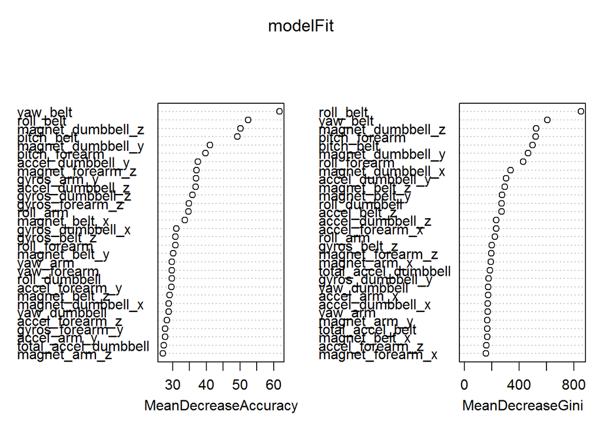

```r
varImpPlot(modelFit)
```

## *DETERMINE OUT OF SAMPLE ACCURACY*

```r
predictions <- predict(modelFit,newdata=testing)
print(predictions)
```

```
##  1  2  3  4  5  6  7  8  9 10 11 12 13 14 15 16 17 18 19 20
##  B  A  B  A  A  E  D  B  A  A  B  C  B  A  E  E  A  B  B  B
## Levels: A B C D E
```

Those 20 answers are all correct.

## *CREATE FILES FOR COURSE PROJECT: SUBMISSION*

```r
pml_write_files = function(x){
  n = length(x)
  for(i in 1:n){
    filename = paste0("problem_id_",i,".txt")
    write.table(x[i],file=filename,quote=FALSE,row.names=FALSE,col.names=FALSE)
  }
}

pml_write_files(predictions)
```